# Datacube processing I

## `terra` approach: stacking raster layers

Exporting your object is the same for raster stacks.

```r
# Export
writeRaster(
  CA_pop_stack,
  "./data/stacks/CA_pop_stack.tif",
  overwrite=TRUE,
  gdal=c("COMPRESS=LZW","BIGTIFF=YES")
)
```

## Exercise 5_1: A raster stack with `terra`

[🖱 Click here to open the exercise](https://denabel.github.io/advanced_geospatial_26/exercises/5_1_Raster_stack_terra.html)

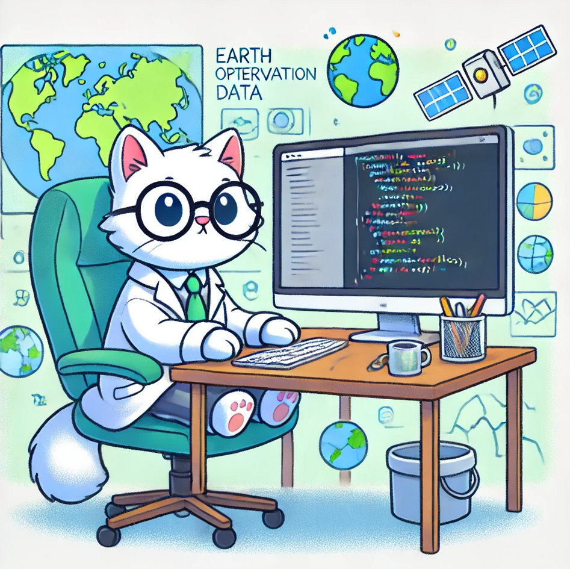

*AI-assisted picture*

## `stars` approach: stacking raster layers

We will now repeat this process with `stars`. We load four layers of population data for California for the years 2017-2020 with `read_stars`.

```r
CA_pop_2017 <- read_stars("./data/worldpop/US-CA_ppp_2017_1km.tif")
CA_pop_2018 <- read_stars("./data/worldpop/US-CA_ppp_2018_1km.tif")
CA_pop_2019 <- read_stars("./data/worldpop/US-CA_ppp_2019_1km.tif")
CA_pop_2020 <- read_stars("./data/worldpop/US-CA_ppp_2020_1km.tif")

class(CA_pop_2017)
```

```
[1] "stars"
```

```r
print(CA_pop_2017)
```

```
stars object with 2 dimensions and 1 attribute
attribute(s), summary of first 1e+05 cells:
                        Min. 1st Qu. Median     Mean    3rd Qu.     Max.  NA's
US-CA_ppp_2017_1km.tif     0       0      0 1.884433 0.09498084 1906.748 60820
dimension(s):
  from   to offset     delta refsys point x/y
x    1 1234 -124.4  0.008333 WGS 84 FALSE [x]
y    1 1136  42.01 -0.008333 WGS 84 FALSE [y]
```

## `stars` approach: stacking raster layers

Concatenating (`c()`) `stars` layers also works.

```r
CA_pop_cube <- c(CA_pop_2017, CA_pop_2018, CA_pop_2019, CA_pop_2020)

class(CA_pop_cube)
```

```
[1] "stars"
```

```r
print(CA_pop_cube)
```

```
stars object with 2 dimensions and 4 attributes
attribute(s), summary of first 1e+05 cells:
                        Min. 1st Qu. Median     Mean    3rd Qu.     Max.  NA's
US-CA_ppp_2017_1km.tif     0       0      0 1.884433 0.09498084 1906.748 60820
US-CA_ppp_2018_1km.tif     0       0      0 1.889280 0.09474182 1919.257 60820
US-CA_ppp_2019_1km.tif     0       0      0 1.894074 0.09462410 1933.029 60820
US-CA_ppp_2020_1km.tif     0       0      0 1.898908 0.09593478 1953.220 60820
dimension(s):
  from   to offset     delta refsys point x/y
x    1 1234 -124.4  0.008333 WGS 84 FALSE [x]
y    1 1136  42.01 -0.008333 WGS 84 FALSE [y]
```

## `stars` approach: stacking raster layers

Again, integrating these steps is more efficient.

**BUT WAIT!** This generates four separate attributes. **This is not what we want!**

```r
files <- list.files("./data/worldpop",
                    pattern = "US-CA_ppp_20(17|18|19|20)_1km\\.tif$",
                    full.names = TRUE)
CA_pop_cube <- read_stars(files)

print(CA_pop_cube)
```

```
stars object with 2 dimensions and 4 attributes
attribute(s), summary of first 1e+05 cells:
    Min. 1st Qu. Median     Mean    3rd Qu.     Max.  NA's
17     0       0      0 1.884433 0.09498084 1906.748 60820
18     0       0      0 1.889280 0.09474182 1919.257 60820
19     0       0      0 1.894074 0.09462410 1933.029 60820
20     0       0      0 1.898908 0.09593478 1953.220 60820
dimension(s):
  from   to offset     delta refsys point x/y
x    1 1234 -124.4  0.008333 WGS 84 FALSE [x]
y    1 1136  42.01 -0.008333 WGS 84 FALSE [y]
```

## `stars` approach: stacking raster layers

We want to integrate the values into one attribute since it is the same variable.

In order to do that, we need to create the time-dimension first.

```r
dates <- as.Date(paste0(2017:2020, "-01-01"))
```

## `stars` approach: stacking raster layers

The `split()` and `merge()` functions allow us to switch dimensions to attributes and the other way round. We can apply the `merge()`-function on our existing datacube to integrate the four attributes into one by supplying the dates:

```r
cube_merged <- merge(CA_pop_cube, f = dates, name = "time")

print(cube_merged)
```

```
stars object with 3 dimensions and 1 attribute
attribute(s), summary of first 1e+05 cells:
             Min. 1st Qu. Median     Mean    3rd Qu.     Max.  NA's
17.18.19.20     0       0      0 1.884433 0.09498084 1906.748 60820
dimension(s):
  from   to     offset     delta refsys point x/y
x    1 1234     -124.4  0.008333 WGS 84 FALSE [x]
y    1 1136      42.01 -0.008333 WGS 84 FALSE [y]
f    1    4 2017-01-01  365 days   Date    NA
```

## `stars` approach: stacking raster layers

A more straightforward approach is to read the layers directly into one object based on the supplied date-variable:

```r
files <- list.files("./data/worldpop",
                    pattern = "US-CA_ppp_20(17|18|19|20)_1km\\.tif$",
                    full.names = TRUE)

# Read layers along time dimension
CA_pop_cube <- read_stars(files, along = list(time = dates))

print(CA_pop_cube)
```

```
stars object with 3 dimensions and 1 attribute
attribute(s), summary of first 1e+05 cells:
                        Min. 1st Qu. Median     Mean    3rd Qu.     Max.  NA's
US-CA_ppp_2017_1km.tif     0       0      0 1.884433 0.09498084 1906.748 60820
dimension(s):
     from   to     offset     delta refsys point x/y
x       1 1234     -124.4  0.008333 WGS 84 FALSE [x]
y       1 1136      42.01 -0.008333 WGS 84 FALSE [y]
time    1    4 2017-01-01  365 days   Date    NA
```

## `stars` approach: stacking raster layers

The `st_dimensions()`and `st_set_dimensions()` functions are super helpful to access and manipulate dimension information. For example, if we want to transform the date into POSIX and assign a timezone, we can do it like this:

```r
layer_posix <- as.POSIXct(dates, tz = "UTC")
CA_pop_cube <- st_set_dimensions(CA_pop_cube,
                                 which = "time",
                                 values = layer_posix)

st_dimensions(CA_pop_cube)$time
```

```
$from
[1] 1

$to
[1] 4

$offset
[1] "2017-01-01 UTC"

$delta
Time difference of 365 days

$refsys
[1] "POSIXct"

$point
[1] NA

$values
NULL

attr(,"class")
[1] "dimension"
```

## `stars` approach: stacking raster layers

We can also simplify the dimension by assigning years as numeric values.

```r
CA_pop_cube <- st_set_dimensions(CA_pop_cube,
                          which = "time",
                          values = 2017:2020)

st_dimensions(CA_pop_cube)$time
```

```
$from
[1] 1

$to
[1] 4

$offset
[1] 2017

$delta
[1] 1

$refsys
[1] NA

$point
[1] NA

$values
NULL

attr(,"class")
[1] "dimension"
```

## `stars` approach: stacking raster layers

In `stars` lingo, our variable is called “attribute”. We can relabel this name as well.

```r
names(CA_pop_cube)
```

```
[1] "US-CA_ppp_2017_1km.tif"
```

```r
names(CA_pop_cube) <- "population"

print(CA_pop_cube)
```

```
stars object with 3 dimensions and 1 attribute
attribute(s), summary of first 1e+05 cells:
            Min. 1st Qu. Median     Mean    3rd Qu.     Max.  NA's
population     0       0      0 1.884433 0.09498084 1906.748 60820
dimension(s):
     from   to offset     delta refsys point x/y
x       1 1234 -124.4  0.008333 WGS 84 FALSE [x]
y       1 1136  42.01 -0.008333 WGS 84 FALSE [y]
time    1    4   2017         1     NA    NA
```

## `stars` approach: stacking raster layers

Setting units in `stars` is not that straightforward and requires a “manual” and quite complicated workaround. Normally, we wouldn’t recommend that.

```r
pop_array <- CA_pop_cube[["population"]]

valid_units <- valid_udunits()

pop_array <- set_units(pop_array, "count")

CA_pop_cube[["population"]] <- pop_array

print(CA_pop_cube)
```

```
stars object with 3 dimensions and 1 attribute
attribute(s), summary of first 1e+05 cells:
                   Min. 1st Qu. Median     Mean    3rd Qu.     Max.  NA's
population [count]    0       0      0 1.884433 0.09498084 1906.748 60820
dimension(s):
     from   to offset     delta refsys point x/y
x       1 1234 -124.4  0.008333 WGS 84 FALSE [x]
y       1 1136  42.01 -0.008333 WGS 84 FALSE [y]
time    1    4   2017         1     NA    NA
```

## `stars` approach: stacking raster layers

Access to the CRS is easy with `st_crs`. The EPSG code is not supplied as string (“EPSG:XXXX”) but as numeric values.

```r
# CRS
st_crs(CA_pop_cube)
```

```
Coordinate Reference System:
  User input: WGS 84
  wkt:
GEOGCRS["WGS 84",
    ENSEMBLE["World Geodetic System 1984 ensemble",
        MEMBER["World Geodetic System 1984 (Transit)"],
        MEMBER["World Geodetic System 1984 (G730)"],
        MEMBER["World Geodetic System 1984 (G873)"],
        MEMBER["World Geodetic System 1984 (G1150)"],
        MEMBER["World Geodetic System 1984 (G1674)"],
        MEMBER["World Geodetic System 1984 (G1762)"],
        MEMBER["World Geodetic System 1984 (G2139)"],
        MEMBER["World Geodetic System 1984 (G2296)"],
        ELLIPSOID["WGS 84",6378137,298.257223563,
            LENGTHUNIT["metre",1]],
        ENSEMBLEACCURACY[2.0]],
    PRIMEM["Greenwich",0,
        ANGLEUNIT["degree",0.0174532925199433]],
    CS[ellipsoidal,2],
        AXIS["geodetic latitude (Lat)",north,
            ORDER[1],
            ANGLEUNIT["degree",0.0174532925199433]],
        AXIS["geodetic longitude (Lon)",east,
            ORDER[2],
            ANGLEUNIT["degree",0.0174532925199433]],
    USAGE[
        SCOPE["Horizontal component of 3D system."],
        AREA["World."],
        BBOX[-90,-180,90,180]],
    ID["EPSG",4326]]
```

```r
# to label if CRS missing - not to reproject
# st_crs(CA_pop_cube) <- 4326
```

## `stars` approach: stacking raster layers

In stars, `st_transform()` changes the CRS of the raster geometry without resampling the cell values. For regular gridded rasters, this produces a curvilinear grid in the target CRS. The cell values remain unchanged, so the operation is lossless with respect to the raster values.

```r
CA_pop_cube_curv <- sf::st_transform(CA_pop_cube,
                                     crs = 3310
                                     )

print(CA_pop_cube_curv)
```

```
stars object with 3 dimensions and 1 attribute
attribute(s), summary of first 1e+05 cells:
                   Min. 1st Qu. Median     Mean    3rd Qu.     Max.  NA's
population [count]    0       0      0 1.884433 0.09498084 1906.748 60820
dimension(s):
     from   to offset delta                    refsys point
x       1 1234     NA    NA NAD83 / California Albers FALSE
y       1 1136     NA    NA NAD83 / California Albers FALSE
time    1    4   2017     1                        NA    NA
                             values x/y
x    [1234x1136] -415118,...,551105 [x]
y    [1234x1136] -607368,...,457879 [y]
time                           NULL
curvilinear grid
```

## `stars` approach: stacking raster layers

To obtain a regular grid is to create a workaround with `st_warp()`. We first specify the target grid with same number of rows and columns and “warp” into that grid.

```r
grid <- st_bbox(CA_pop_cube) |>
  st_as_sfc() |>
  st_transform(crs = 3310) |>
  st_bbox() |>
  st_as_stars(nx = dim(CA_pop_cube)["x"],
              ny = dim(CA_pop_cube)["y"])

CA_pop_cube <- st_warp(CA_pop_cube, grid)

print(CA_pop_cube)
```

```
stars object with 3 dimensions and 1 attribute
attribute(s), summary of first 1e+05 cells:
                   Min. 1st Qu. Median     Mean   3rd Qu.     Max.  NA's
population [count]    0       0      0 2.112075 0.1045545 1906.748 71165
dimension(s):
     from   to  offset delta                    refsys x/y
x       1 1234 -415531 783.7 NAD83 / California Albers [x]
y       1 1136  458361  -930 NAD83 / California Albers [y]
time    1    4    2017     1                        NA
```

## `stars` approach: stacking raster layers

Indexing `stars` objects differs a bit compared to `SpatRaster`. Given that `stars` objects can store more than one attribute (variable), we need to consider four levels:

```r
# Return stars object and drop all attributes except "population"
class(CA_pop_cube["population"])
```

```
[1] "stars"
```

```r
# Drop stars metadata and just pull out array of attribute "population
str(CA_pop_cube[["population"]])
```

```
 Units: [count] num [1:1234, 1:1136, 1:4] NA NA NA NA NA NA NA NA NA NA ...
```

```r
# Same
str(CA_pop_cube$population)
```

```
 Units: [count] num [1:1234, 1:1136, 1:4] NA NA NA NA NA NA NA NA NA NA ...
```

```r
# Spatial slicing on four levels
CA_pop_cube[1, # which attribute
            , # x
            , # y
            ] # which time
```

```
stars object with 3 dimensions and 1 attribute
attribute(s), summary of first 1e+05 cells:
                   Min. 1st Qu. Median     Mean   3rd Qu.     Max.  NA's
population [count]    0       0      0 2.112075 0.1045545 1906.748 71165
dimension(s):
     from   to  offset delta                    refsys x/y
x       1 1234 -415531 783.7 NAD83 / California Albers [x]
y       1 1136  458361  -930 NAD83 / California Albers [y]
time    1    4    2017     1                        NA
```

```r
# Here we select attribute 1 across all dimensions

# All data for first time-slice
CA_pop_cube[ , , , 1]
```

```
stars object with 3 dimensions and 1 attribute
attribute(s), summary of first 1e+05 cells:
                   Min. 1st Qu. Median     Mean   3rd Qu.     Max.  NA's
population [count]    0       0      0 2.112075 0.1045545 1906.748 71165
dimension(s):
     from   to  offset delta                    refsys x/y
x       1 1234 -415531 783.7 NAD83 / California Albers [x]
y       1 1136  458361  -930 NAD83 / California Albers [y]
time    1    1    2017     1                        NA
```

```r
# Specifying x and y window
CA_pop_cube[ ,1:100 ,1:100 , ]
```

```
stars object with 3 dimensions and 1 attribute
attribute(s):
                   Min. 1st Qu.   Median     Mean  3rd Qu.    Max.  NA's
population [count]    0       0 0.102222 26.68345 4.999558 1953.22 35960
dimension(s):
     from  to  offset delta                    refsys x/y
x       1 100 -415531 783.7 NAD83 / California Albers [x]
y       1 100  458361  -930 NAD83 / California Albers [y]
time    1   4    2017     1                        NA
```

## `stars` approach: stacking raster layers

There is also a native export function for `stars` objects.

```r
write_stars(CA_pop_cube,
            "./data/stacks/CA_pop_cube.tif",
            driver = "GTiff",
            options = c("COMPRESS=LZW", "BIGTIFF=YES")
            )
```

## `stars` approach: stacking raster layers

The **GeoTIFF** format will store the most important data on cell values, x, y, and “bands” and the associated CRS. However, it will discard our coding of the time metadata. If we want to export the `stars` object for `R` usage only, we can simply store it as `.rds`-file to preserve the entire dataset. Exporting for external usage which preserves the extra dimensions can be done in **NetCDF** format.

```r
saveRDS(CA_pop_cube, "./data/stacks/CA_pop_cube.rds")

write_stars(CA_pop_cube,
            "./data/stacks/CA_pop_cube.nc",
            driver = "netCDF")
```

## Converting between `terra` and `stars`

In theory, converting between `terra` and `stars` objects is simple. This will preserve most crucial information on cell values, spatial extent, and CRS. It can, however, mess around with your neatly prepared metadata.

```r
# Transform terra SpatRaster into stars object
CA_pop_stack_stars <- stars::st_as_stars(CA_pop_stack)

class(CA_pop_stack_stars)
```

```
[1] "stars"
```

```r
print(CA_pop_stack_stars)
```

```
stars object with 3 dimensions and 1 attribute
attribute(s), summary of first 1e+05 cells:
          Min. 1st Qu. Median     Mean   3rd Qu.     Max.  NA's
pop_2017     0       0      0 2.002445 0.1364381 1267.249 71344
dimension(s):
     from   to  offset  delta                    refsys x/y
x       1 1168 -415531  828.3 NAD83 / California Albers [x]
y       1 1287  458361 -828.3 NAD83 / California Albers [y]
time    1    4    2017      1                        NA
```

## Converting between `terra` and `stars`

In theory, converting between `terra` and `stars` objects is simple. This will preserve most crucial information on cell values, spatial extent, and CRS. It can, however, mess around with your neatly prepared metadata.

```r
# Transform stars object into terra SpatRaster
# Terra has problems with handling stars time-dimension -> transform into attribute
cube_prepped <- split(CA_pop_cube, "time")
CA_pop_cube_terra <- terra::rast(cube_prepped)

class(CA_pop_cube_terra)
```

```
[1] "SpatRaster"
attr(,"package")
[1] "terra"
```

```r
print(CA_pop_cube_terra)
```

```
class       : SpatRaster
size        : 1136, 1234, 4  (nrow, ncol, nlyr)
resolution  : 783.6756, 930.0241  (x, y)
extent      : -415531, 551524.7, -598145.9, 458361.4  (xmin, xmax, ymin, ymax)
coord. ref. : NAD83 / California Albers (EPSG:3310)
source(s)   : memory
names       :    X1_X1, X2_X2,    X3_X3,    X4_X4
min values  :     0.00,     0,     0.00,     0.00
max values  : 29224.54, 29316, 29433.52, 29535.46
```

## Exercise 5_2: A raster cube with `stars`

[🖱 Click here to open the exercise](https://denabel.github.io/advanced_geospatial_26/exercises/5_2_Raster_cube_stars.html)

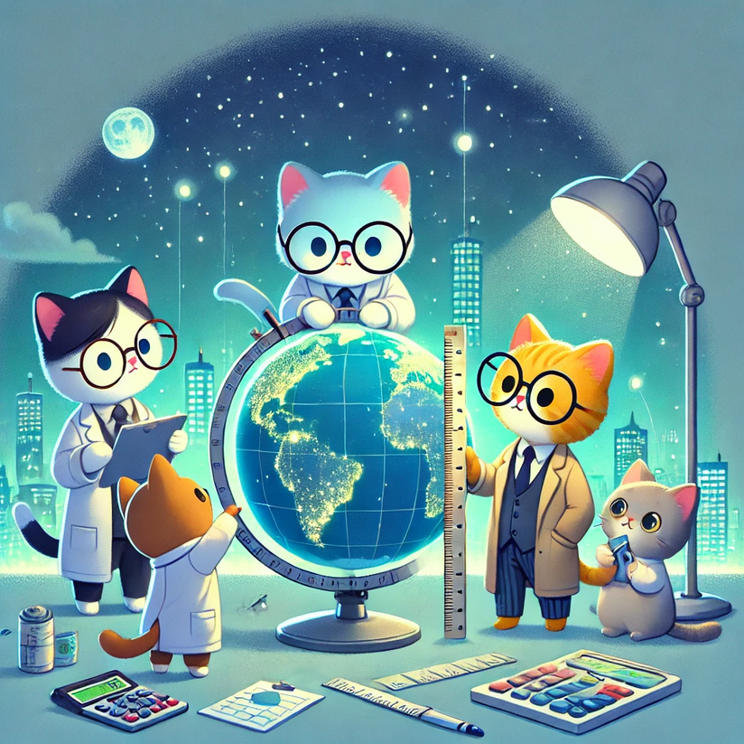

*AI-assisted picture*